## Background information

This project is from Jesse Gray’s lab, they are interested in looking at the composition of the enhancer sequences they had synthesized and stuck into some viral vectors; there are several subsets of enhancers, some from mouse and human and the mouse enhancers have several positive and negative controls. The enhancer sequences we barcoded with a 16mer and they are interested in looking at what the barcode distribution looks like as well.

Most of the enhancer sequences are ~ 140mers in a sliding window across ~ 600 full length enhancer sequences. We don’t have the full sequences available yet but they are floating around somewhere. There are about ~ 12k enhancer fragments that were synthesized.

As a first iteration, we did something super simple to get to this point, we took the enhancer fragments and made a bwa database, then aligned the reads to those. Before aligning the reads we stuck the barcode for each read in the read name, so we could figure out which barcode was associated with an alignment. Then we parsed the alignment file to dump which enhancer sequence it aligned to, along with the barcode that was used and some numbers about mapping quality and number of mismatches along with the sequence that was sequenced. The code to do all of this, and this report, is up on github [here](https://github.com/hbc/gray-enhancers).

```r
> require(ggplot2)
> library(knitr)
> library(plyr)
> library(dplyr)
> in_file = "../tsv/read_table.tsv"
> dat = read.table(in_file, header = TRUE, sep = "\t")
> # remove the reads which did not align to an enhancer
> dat = tbl_df(dat[!is.na(dat$eid), ])
> dat$differences = dat$mismatch + dat$insertions + dat$deletions + dat$clipped
> sequencing_depth = dat %>% group_by(barcode, eid) %>% summarise(count = n()) %>%
+     ungroup()
>
> nreads = nrow(dat)
> unique_barcodes = unique(dat$barcode)
> nunique_barcodes = length(unique_barcodes)
> unique_reads = unique(dat[, c("barcode", "eid")])
```

The original FASTQ file has about 24 million reads in it, so that is the starting point. Aligning those reads to the set of enhancer sequences generates 15649011 total alignments, with 320842 unique barcode-enhancer pairs represented in those alignments which means many of the barcode-enhancer pairs have multiple alignments representing them. Of the 320842 unique barcode-enhancer pairs, there are 272619 unique barcodes represented, so some barcodes are doing double double duty and either aligning to more than one enhancer sequence or are attached to multiple enhancer sequences.

Previous work looking at random barcoding of sequences has shown that the barcodes with only one read of evidence for them tend to be sequencing errors:

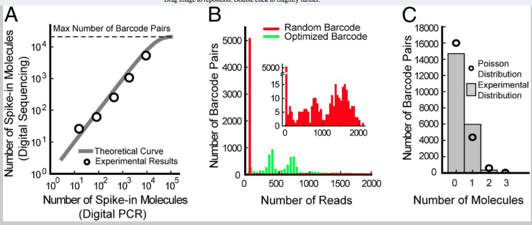

It looks like we can dump barcodes that only appear a small number of times, not just 1 and remove some more noise from the data.

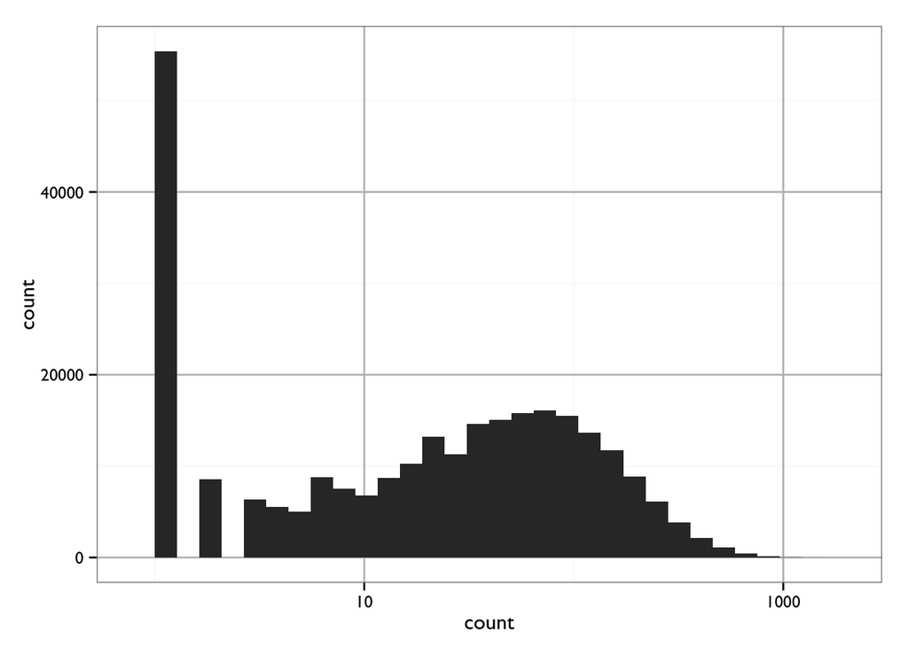

```r
> detach("package:dplyr")
> library(dplyr)
> grouped = dat %>% group_by(barcode) %>% summarise(count = n()) %>% ungroup()
> ggplot(grouped, aes(count)) + geom_histogram() + scale_x_log10() + theme_bw(base_size = 12,
+     base_family = "Gill Sans") + theme(panel.grid.major = element_line(size = 0.5,
+     color = "grey"))
```

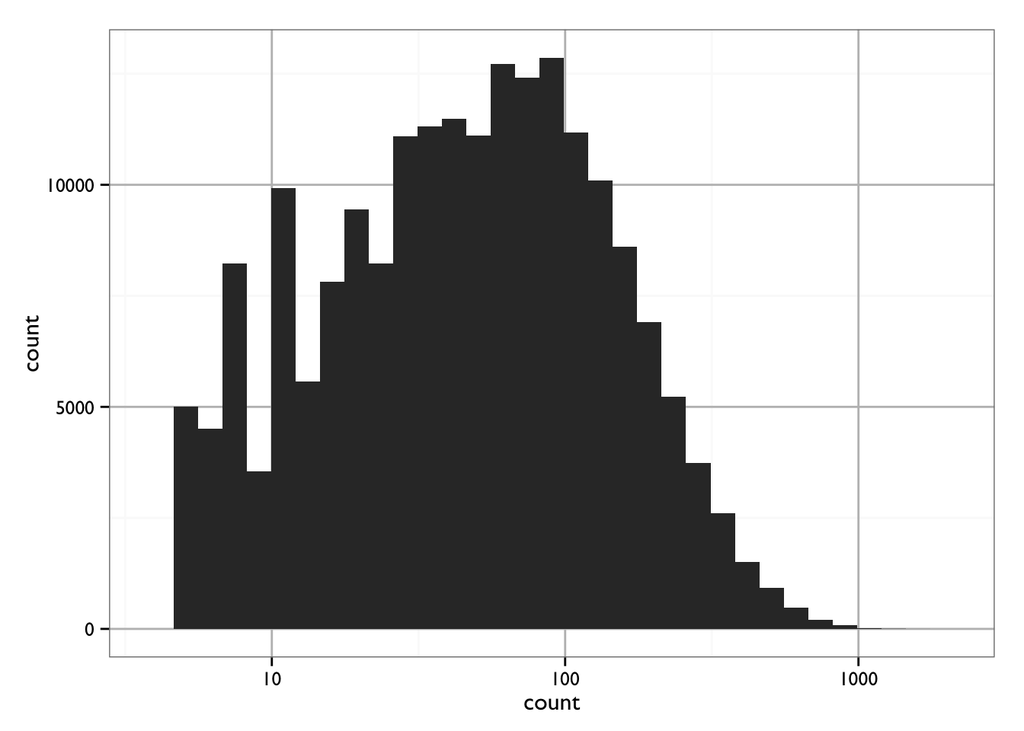

```r
> dat = dat %>% group_by(barcode) %>% filter(n() > 4) %>% ungroup()
> grouped = dat %>% group_by(barcode) %>% summarise(count = n())
> ggplot(grouped, aes(count)) + geom_histogram() + scale_x_log10() + theme_bw(base_size = 12,
+     base_family = "Gill Sans") + theme(panel.grid.major = element_line(size = 0.5,
+     color = "grey"))
```

This leaves us with 15535464 total alignments to work with and 196827 barcodes. If we further restrict and now group by eid and barcode instead of just barcode, we can identify another set of likely-erroneous barcode + eid combinations to remove. The idea behind this is that if a barcode + eid is really present in the sample, we should have sequenced more than one read for it and generate more than one alignment for that barcode.

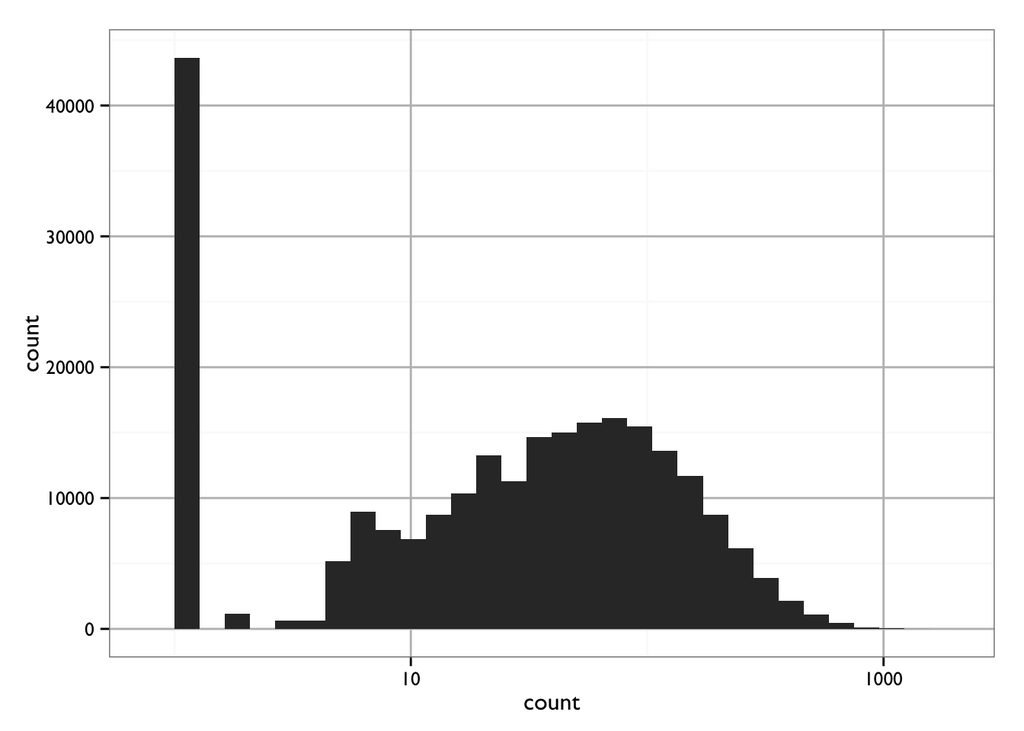

```r
> likely_erroneous = dat %>% group_by(barcode, eid) %>% summarise(count = n())
> ggplot(likely_erroneous, aes(count)) + geom_histogram() + scale_x_log10() +
+     theme_bw(base_size = 12, base_family = "Gill Sans") + theme(panel.grid.major = element_line(size = 0.5,
+     color = "grey"))
```

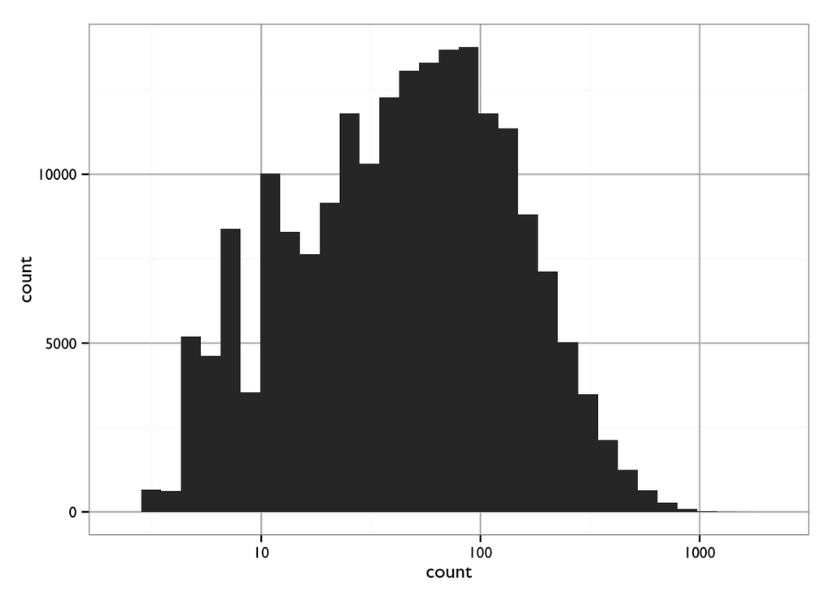

```r
> dat = dat %>% group_by(barcode, eid) %>% filter(n() > 2)
> filtered_depth = dat %>% group_by(barcode, eid) %>% summarise(count = n())
> ggplot(filtered_depth, aes(count)) + geom_histogram() + scale_x_log10() + theme_bw(base_size = 12,
+     base_family = "Gill Sans") + theme(panel.grid.major = element_line(size = 0.5,
+     color = "grey"))
```

After that initial cleaning, we have a table *dat* which is a set of 15489488 alignments where we have removed alignments where we thought it was pretty likely the barcode was wrong due to a sequencing error. Some of these alignments are seen repeatedly. Here we group alignments by barcode, eid, the number of differences, the mapping quality and the score of the primary and secondary alignments to identify alignments that are identical.

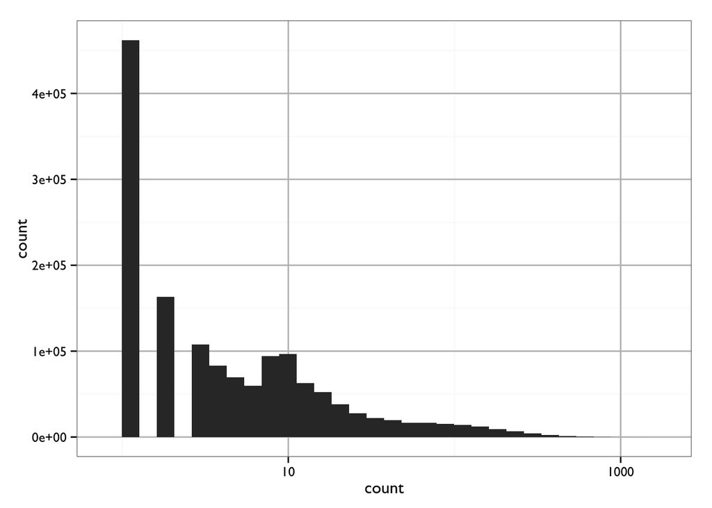

```r
> cleaned = dat[, 2:ncol(dat)] %>% group_by(barcode, eid, differences, mapq, as,
+     xs) %>% mutate(count = n()) %>% ungroup() %>% distinct()
> ggplot(cleaned, aes(count)) + geom_histogram() + scale_x_log10() + theme_bw(base_size = 12,
+     base_family = "Gill Sans") + theme(panel.grid.major = element_line(size = 0.5,
+     color = "grey"))
```

This gets us down to 1459112 distinct alignments. From the above plot we can see there are many alignments that appear only a small number of times. These are again likely errors, but this time in the enhancer sequence, not the barcodes.

Here is an example from one barcode + eid combination:

```r
> x = subset(cleaned, barcode == "TGGCTGGTGTTGTAGT")
> x$count
```

```
 [1] 187  11  11   1  11  11  11  11   1  11   1  11  11  11  11
```

```r
> subset(x[, c("barcode", "eid", "differences", "mismatch", "count", "as", "xs")],
+     count > 10)
```

```
Source: local data frame [12 x 7]

            barcode      eid differences mismatch count  as  xs
1  TGGCTGGTGTTGTAGT 63406153           5        3   187 124 103
2  TGGCTGGTGTTGTAGT 63406153           6        4    11 119  98
3  TGGCTGGTGTTGTAGT 63406153           6        4    11 119  98
4  TGGCTGGTGTTGTAGT 63406153           6        4    11 119  98
5  TGGCTGGTGTTGTAGT 63406153           6        4    11 119  98
6  TGGCTGGTGTTGTAGT 63406153           6        4    11 119  98
7  TGGCTGGTGTTGTAGT 63406153           6        4    11 119  98
8  TGGCTGGTGTTGTAGT 63406153           6        4    11 119  98
9  TGGCTGGTGTTGTAGT 63406153           6        4    11 119  98
10 TGGCTGGTGTTGTAGT 63406153           6        4    11 119  98
11 TGGCTGGTGTTGTAGT 63406153           6        4    11 119  98
12 TGGCTGGTGTTGTAGT 63406153           6        4    11 119  98
```

So another useful filtering is to take only the barcode+eid that we have seen the most, and we will call this the true sequence going forward.

```r
> clean = cleaned %>% group_by(barcode, eid) %>% filter(count == max(count)) %>%
+     ungroup()
```

Now we can break down what these look like.

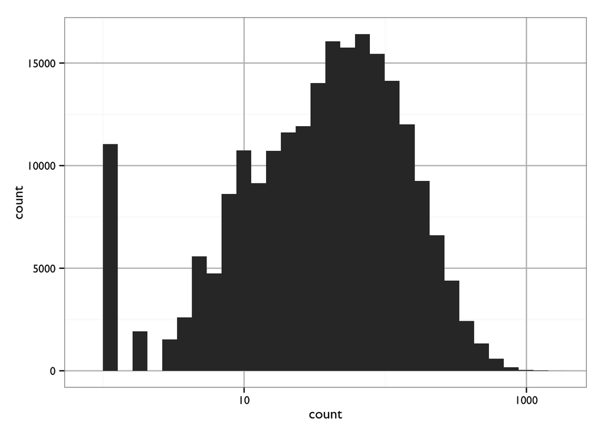

```r
> ggplot(clean, aes(count)) + geom_histogram() + scale_x_log10() + theme_bw(base_size = 12,
+     base_family = "Gill Sans") + theme(panel.grid.major = element_line(size = 0.5,
+     color = "grey"))
```

It looks like we can do one final filtering, filter out barcode+eid sequences where the most common hit has < 10 counts.

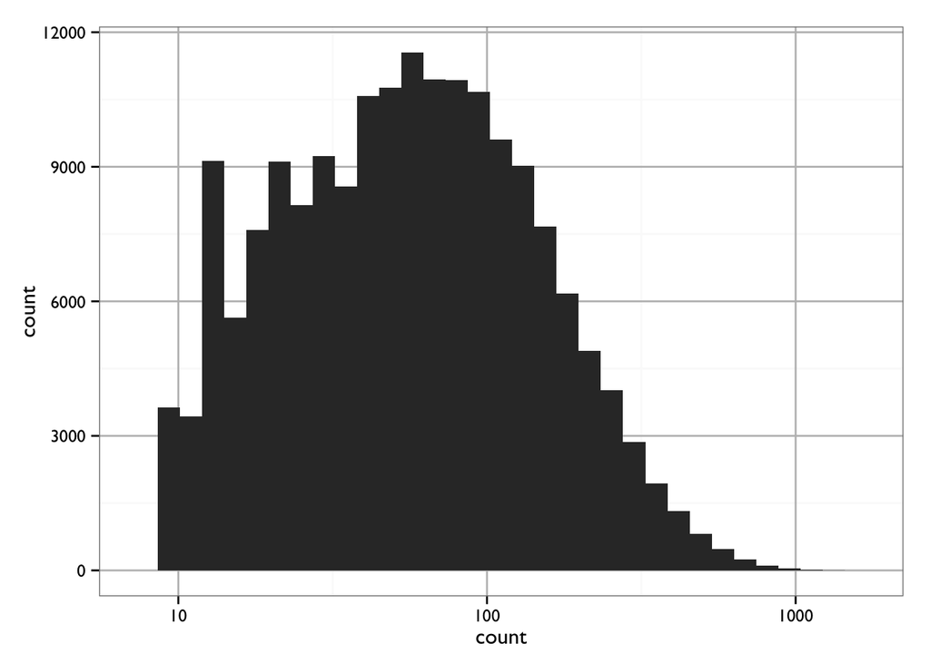

```r
> clean = subset(clean, count >= 10)
> ggplot(clean, aes(count)) + geom_histogram() + scale_x_log10() + theme_bw(base_size = 12,
+     base_family = "Gill Sans") + theme(panel.grid.major = element_line(size = 0.5,
+     color = "grey"))
```

```r
> exact = subset(clean, differences == 0)
```

That leaves us with 179161 barcode + enhancer sequences to consider. Those are represented by 171143 barcodes and 9126 enhancer ids.

59519 of the barcode + eid sequences are exact matches to the enhancer sequences, representing 6884 distinct enhancer sequences.

Each enhancer sequence is represented multiple by multiple barcodes:

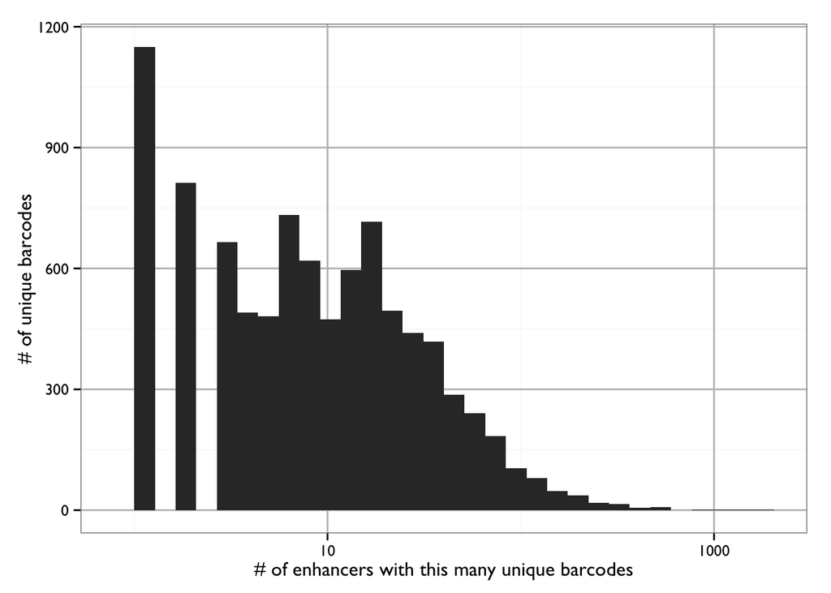

```r
> reads_per_eid = clean %>% group_by(eid) %>% summarise(count = n())
> ggplot(reads_per_eid, aes(count)) + geom_histogram() + scale_x_log10() + xlab("# of enhancers with this many unique barcodes") +
+     ylab("# of unique barcodes") + theme_bw(base_size = 12, base_family = "Gill Sans") +
+     theme(panel.grid.major = element_line(size = 0.5, color = "grey"))
```

Below is a plot in the other direction, the number of times each barcode is seen. Most barcodes are uniquely used and are seen only on a single enchancer one we remove the likely erroneous barcodes.

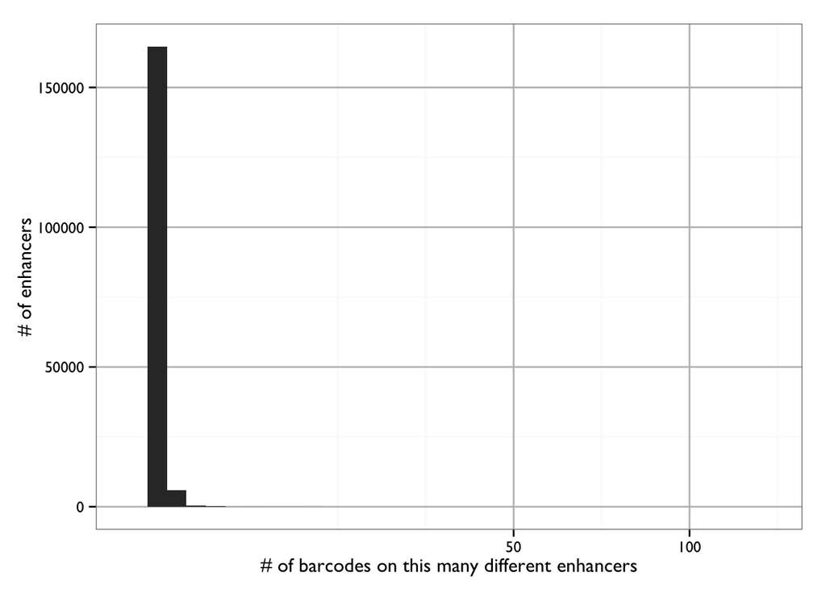

```r
> reads_per_barcode = clean %>% group_by(barcode) %>% summarize(count = n())
> ggplot(reads_per_barcode, aes(count)) + geom_histogram() + scale_x_sqrt() +
+     ylab("# of enhancers") + xlab("# of barcodes on this many different enhancers") +
+     theme_bw(base_size = 12, base_family = "Gill Sans") + theme(panel.grid.major = element_line(size = 0.5,
+     color = "grey"))
```

Some enhancers had better mapping quality than others. It looks like it separates out by subtype.

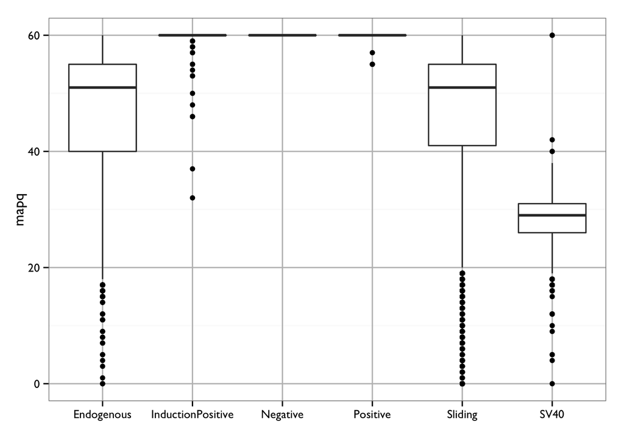

```r
> ggplot(clean, aes(subtype, mapq)) + geom_boxplot() + theme_bw(base_size = 12,
+     base_family = "Gill Sans") + xlab("") + theme(panel.grid.major = element_line(size = 0.5,
+     color = "grey"))
```

Similarly, there is less of a spread of the differences to the best hit, though the sliding and endongenous subtypes seem to have and enrichment for a low number of mismatches.

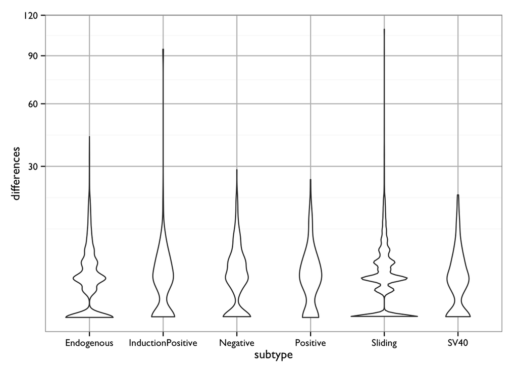

```r
> ggplot(clean, aes(subtype, differences)) + geom_violin() + theme_bw(base_size = 12,
+     base_family = "Gill Sans") + scale_y_sqrt() + theme(panel.grid.major = element_line(size = 0.5,
+     color = "grey"))
```

In general, mapping quality decreases with the number of differences with the enhancer sequence, but there is a range at each value.

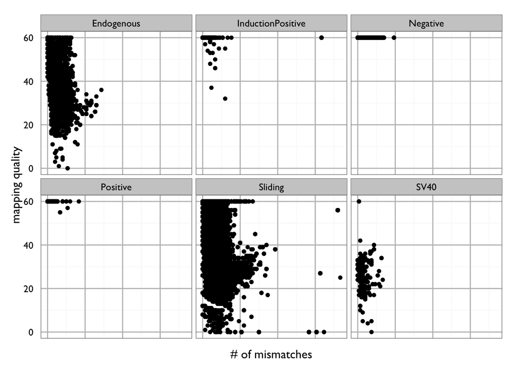

```r
> ggplot(clean, aes(differences, mapq)) + geom_point() + facet_wrap(~subtype) +
+     xlab("# of mismatches") + ylab("mapping quality") + theme_bw(base_size = 12,
+     base_family = "Gill Sans") + theme(panel.grid.major = element_line(size = 0.5,
+     color = "grey"), axis.ticks = element_blank(), axis.text.x = element_blank())
```

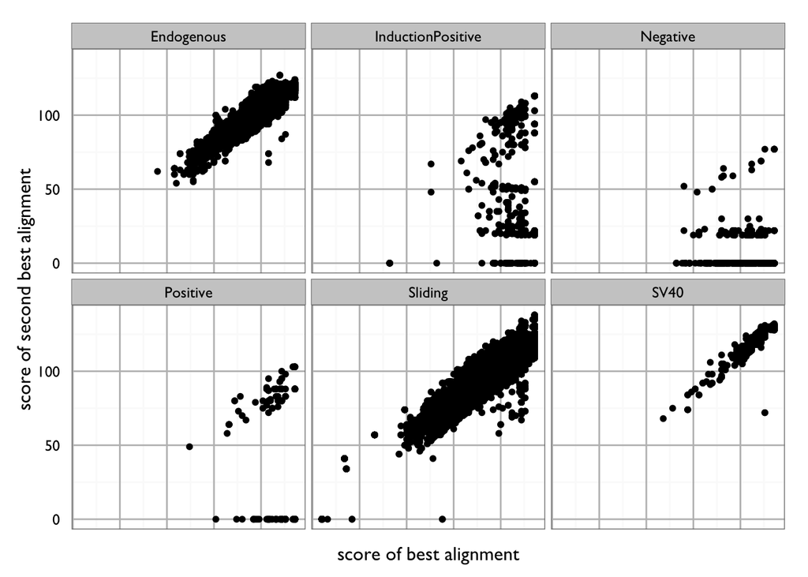

```r
> ggplot(clean, aes(as, xs)) + geom_point() + facet_wrap(~subtype) + xlab("score of best alignment") +
+     ylab("score of second best alignment") + theme_bw(base_size = 12, base_family = "Gill Sans") +
+     theme(panel.grid.major = element_line(size = 0.5, color = "grey"), axis.ticks = element_blank(),
+         axis.text.x = element_blank())
```

Some enhancer sequences don’t have a best hit. Here are the enhancer sequences that are missing:

```r
> enhancer_fn = "../metadata/enhancer.tsv"
> enhancers = read.table(enhancer_fn, header = TRUE, stringsAsFactors = FALSE)
> enhancers$seen = enhancers$eid %in% clean$eid
> nmissing = nrow(subset(enhancers, !seen))
> nseen = nrow(subset(enhancers, seen))
> out_table = data.frame(table(enhancers$seen))
> colnames(out_table) = c("seen", "count")
> kable(out_table, format = "html")
```

| seen | count |
| --- | --- |
| FALSE | 3346 |
| TRUE | 9126 |

```r
> out_table = data.frame(table(enhancers[, c("subtype", "seen", "species")]))
> colnames(out_table) = c("subtype", "seen", "species", "count")
> kable(out_table, format = "html")
```

| subtype | seen | species | count |
| --- | --- | --- | --- |
| Endogenous | FALSE | hs | 160 |
| InductionPositive | FALSE | hs | 0 |
| Negative | FALSE | hs | 0 |
| Positive | FALSE | hs | 0 |
| Sliding | FALSE | hs | 1714 |
| SV40 | FALSE | hs | 0 |
| Endogenous | TRUE | hs | 403 |
| InductionPositive | TRUE | hs | 0 |
| Negative | TRUE | hs | 0 |
| Positive | TRUE | hs | 0 |
| Sliding | TRUE | hs | 3916 |
| SV40 | TRUE | hs | 0 |
| Endogenous | FALSE | mm | 124 |
| InductionPositive | FALSE | mm | 1 |
| Negative | FALSE | mm | 6 |
| Positive | FALSE | mm | 1 |
| Sliding | FALSE | mm | 1340 |
| SV40 | FALSE | mm | 0 |
| Endogenous | TRUE | mm | 439 |
| InductionPositive | TRUE | mm | 26 |
| Negative | TRUE | mm | 29 |
| Positive | TRUE | mm | 8 |
| Sliding | TRUE | mm | 4290 |
| SV40 | TRUE | mm | 15 |

```r
> write.table(subset(enhancers, !seen), file = "missing_enhancers.csv", quote = FALSE,
+     sep = ",", col.names = TRUE, row.names = FALSE)
```

Finally we write out the cleaned data to a big table. This table has for each barcode and enhancer sequence the number of mismatches, indels, etc for the alignment to the specified enhancer sequence. The alignment is the best hit for the sequence and the mismatches are likely synthesis errors, because we saw them in at least 10 separate identical reads. The consensus sequence that generated the best hit is in the seq column of the table.

```r
> write.table(clean, file = "clean.tsv", quote = FALSE, sep = ",", col.names = TRUE,
+     row.names = FALSE)
```